# ENLIGHT Open Science Survey 2024

Author

Birgit Schmidt

Published

May 31, 2024

# Results from the survey on Open Science 2024

This report provides an update on Open Science (OS) across the ENLIGHT university network based on a survey that was conducted in February/March 2024. The survey was open from 6 February until 12 March 2024.

Each of the ten partner universities provided one response, completed by library and research support staff. The University of Bern joined ENLIGHT on 1 December 2022, and is therefore included in this edition of the OS survey but not in the 2022 edition. All respondent names and other names mentioned were removed in the final dataset.

The survey was divided into 9 parts: general information, assessment of OS activities, infrastructures and support, skills and knowledge, community activities, policy, recognition and rewards, looking into the future (after the end of ENLIGHT RISE), and finally research data management and FAIR data.

Compared to the surveys from 2022, the questions on Open Science and research data management were integrated. Moreover, questions targeting views on joint achievements and possible future actions were added.

The main areas and focus of the second survey were to

- Update the information of the previous survey on Open Science (OS), Open Access (OA) and research data management (RDM) activities,
- Identify achievements based on the ENLIGHT RISE activities, and
- Identify topics and priorities for continued collaboration on Open Science in ENLIGHT.

The survey findings will be published in the ENLIGHT Open Science Status Quo & Opportunities #2 (deliverable D7.2) report.

## Levels of OS activity

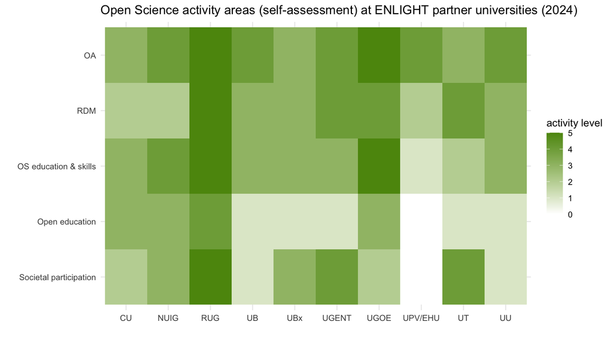

```r
options(repr.plot.width = 10, repr.plot.height = 5)

os_activities_2024 <- os_survey_2024 %>% select(institution, oa:societal_part)  %>% mutate(institution = factor(institution)) %>% pivot_longer(oa:societal_part, names_to = "activity_type", values_to = "activity_level") %>% mutate(activity_type = factor(activity_type, levels = c("oa", "rdm", "os_edu_skills", "open_edu", "societal_part"), labels = c("OA", "RDM", "OS education & skills", "Open education", "Societal participation")))

#' mosaic plot of OS activities
#' (factor in inverse order due to flip of coordinates)
os_activities_2024 %>% ggplot(aes(institution, fct_rev(activity_type))) + geom_tile(aes(fill = activity_level)) + scale_fill_gradient(low = "white", high = "#5c940d") + ylab("") + xlab("") + theme_minimal() + labs(fill = "activity level") + ggtitle("Open Science activity areas (self-assessment) at ENLIGHT partner universities (2024)")

ggsave("plots/os-activities-2024.png", width = 9, height = 5, units = "in")
```

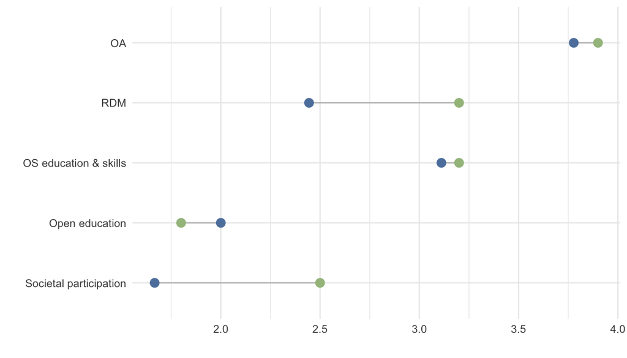

Figure 2: Comparison of Open Science activity areas at ENLIGHT partner universities (2024 vs. 2022, average across 9 universities)

```r
library(ggplot2)

# compute the difference of the average for 2024 vs. 2022
os_survey_2022_nine <- os_survey_2022 %>% filter(!(institution == "UB"))

#os_activities_2022_avg <- os_survey_2022_nine %>% mutate_at(c(oa:societal_part), mean)
#os_activities_2024_avg <- os_survey_2024 %>% mutate_at(c(oa:societal_part), mean)

os_activities_avg <- os_survey_all %>% select(oa:societal_part, year) %>% group_by(year) %>% summarise(across(c(oa:societal_part), mean))

os_activities_avg_t <- transpose(os_activities_avg)
os_activities_avg_t$activity_type <- colnames(os_activities_avg)
colnames(os_activities_avg_t) <- c("value1", "value2", "activity_type")

os_activities_avg_tt <- os_activities_avg_t[-1, ]
os_activities_avg_tt <- os_activities_avg_tt %>% mutate(activity_type = factor(activity_type, levels = c("oa", "rdm", "os_edu_skills", "open_edu", "societal_part"), labels = c("OA", "RDM", "OS education & skills", "Open education", "Societal participation")))

# Plot
ggplot(os_activities_avg_tt) +
  geom_segment(aes(x=fct_rev(activity_type), xend=activity_type, y=value1, yend=value2), color="grey") +
  geom_point( aes(x=activity_type, y=value1), color= "#5e81ac", size=3 ) +
  geom_point( aes(x=activity_type, y=value2), color= "#a3be8c", size=3 ) +
  coord_flip() +
  theme_minimal() +
  theme(
    legend.position = "none",
  ) +
  xlab("") +
  ylab("")
```

The figure compares the mean activity levels for the five core OS activity areas as reported in 2024 (green) compared to 2022 (blue). The University of Bern was excluded in this comparison as they did not participate in the 2022 edition of the survey.

For almost all OS areas some growth of the mean values based on the nine considered ENLIGHT partner universities could be observed. The strongest growth of activity levels was observed for research data management and societal participation. Only small gains were achieved for OA and OS education and skills (starting from high levels of activity) while a small reduction of activity was reported for open education (starting from modest level).

The greatest diversity in terms of uptake and the largest room for improvements seems to be in open education and societal engagement.

## Infrastructures and support

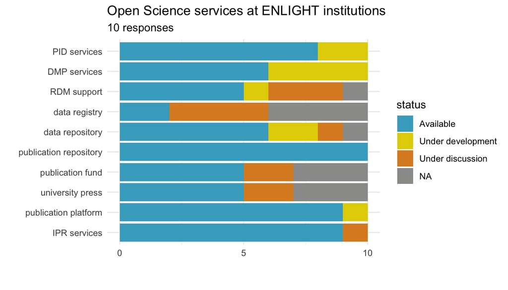

```r
os_services_2024 <- os_survey_2024 %>%
  select(institution, services_pub_repo:services_uni_press) %>%
  pivot_longer(services_pub_repo:services_uni_press, names_to = "service", values_to = "status") %>%
  mutate(status = replace_na(status, "NA")) %>%
  mutate(service = factor(service, levels = c("services_ipr",  "services_pub_platform", "services_uni_press",  "services_pub_fund",  "services_pub_repo", "services_data_repo", "services_data_reg",  "services_rdm_support", "services_dmp", "services_pid" ), labels = c("IPR services", "publication platform","university press", "publication fund", "publication repository", "data repository", "data registry", "RDM support", "DMP services", "PID services")), status = factor(status, levels = c("NA", "Under discussion", "Under development", "Available")))


standard_plot3(os_services_2024, service, fill = status, title = "Open Science services at ENLIGHT institutions", m = 10, subtitle = "responses", caption = "") + scale_y_continuous(limits = c(0,10), breaks = c(0, 5, 10))
```

## OS training

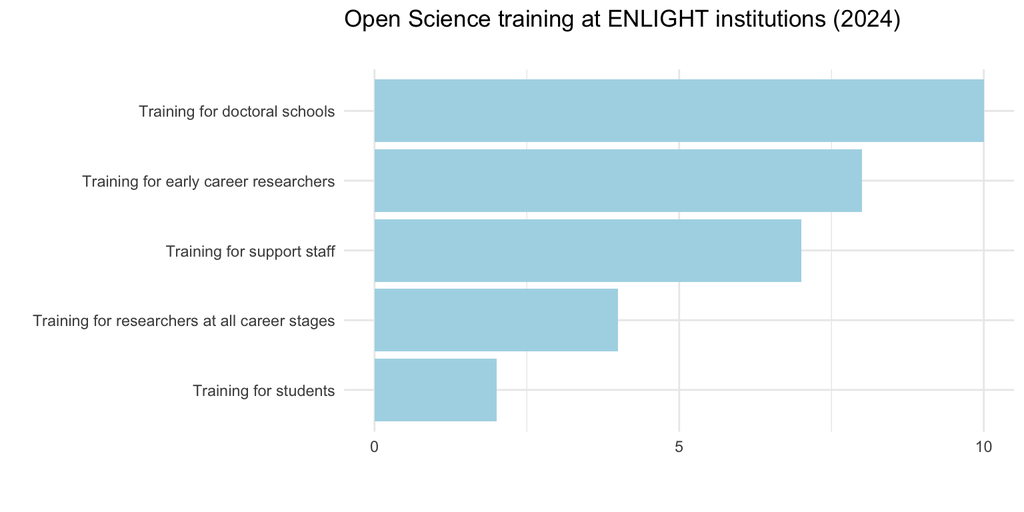

```r
# "os_training"
# "os_training_topics"
# "enlight_training_topics"

# OS training
os_survey_os_training_2024 <- os_survey_2024 %>%
  select(Zeitstempel, os_training) %>%
  transform(os_training = strsplit(os_training, ",")) %>%
  unnest(os_training)  %>%
  transform(os_training = str_trim(os_training, side = "both")) %>%
  as_tibble() %>%
  filter(!is.na(os_training)) %>%
  mutate(os_training = factor(os_training))

# standard answers
os_training_targets <- unique(os_survey_os_training_2024$os_training) %>% str_subset("Training for")

os_survey_os_training_2024 <- os_survey_os_training_2024 %>% filter(os_training %in% os_training_targets)

standard_plot(os_survey_os_training_2024, os_training, title = "Open Science training at ENLIGHT institutions (2024)", subtitle = "", caption = "") +
  scale_y_continuous(limits = c(0,10), breaks = c(0, 5, 10))
```

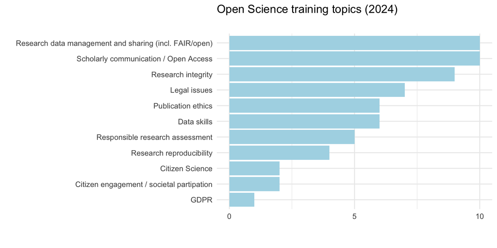

```r
# OS training topics
os_survey_os_training_topics_2024 <- os_survey_2024 %>%
  select(Zeitstempel, os_training_topics) %>%
  transform(os_training_topics = strsplit(os_training_topics, ",")) %>%
  unnest(os_training_topics)  %>%
  transform(os_training_topics = str_trim(os_training_topics, side = "both")) %>%
  as_tibble() %>%
  filter(!is.na(os_training_topics)) %>%
  mutate(os_training_topics = factor(os_training_topics))

os_survey_os_training_topics_2024 <- os_survey_os_training_topics_2024 %>% filter(!(os_training_topics %in% c("See previous note", "etc.)", "IPR", "licensing", "processing", "preprints", "evaluation of the quality of publication outlets", "societal participation"))) %>%
  mutate(os_training_topics = recode_factor(os_training_topics, "Data skills (creating/collecting" = "Data skills", "Scholarly communication (Open Access" = "Scholarly communication / Open Access", "Legal issues (IPR" = "Legal issues", "Research data management and sharing (incl. FAIR)" = "RDM, FAIR data, data sharing", "Responsible research assessment (incl. impact metrics)" = "Responsible research assessment", "data publishing" = "Data publishing", "Publication ethics (peer review" = "Publication ethics", "Citizen engagement" = "Citizen engagement / societal partipation"))

standard_plot(os_survey_os_training_topics_2024, os_training_topics, title = "Open Science training topics (2024)", subtitle = "", caption = "") + scale_y_continuous(limits = c(0,10), breaks = c(0, 5, 10))
```

## Community activities

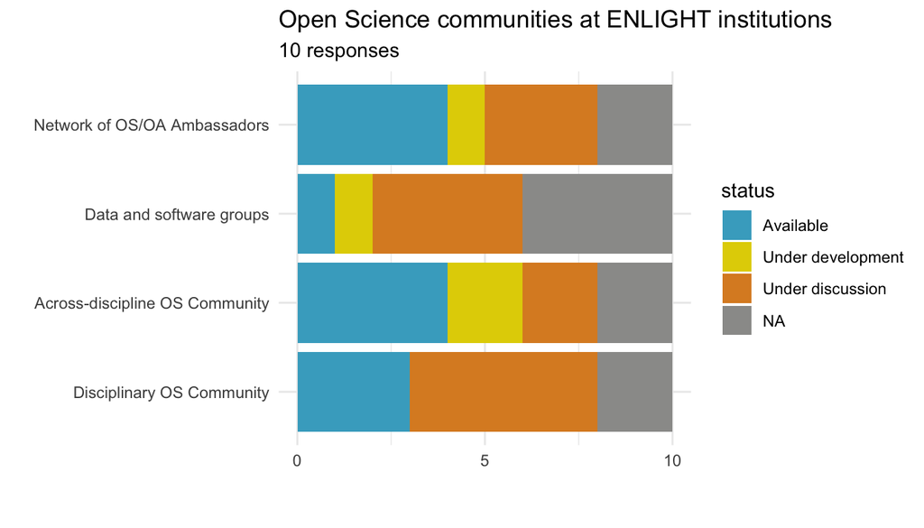

```r
os_community_2024 <- os_survey_2024 %>%
  select(institution, os_community_disc:os_community_ambass) %>%
  pivot_longer(os_community_disc:os_community_ambass, names_to = "community", values_to = "status") %>%
  mutate(status = replace_na(status, "NA")) %>%
  mutate(community = factor(community, levels = c("os_community_disc", "os_community_across_disc", "os_community_os","os_community_ambass"), labels = c("Disciplinary OS Community", "Across-discipline OS Community","Data and software groups", "Network of OS/OA Ambassadors")), status = factor(status, levels = c("NA", "Under discussion", "Under development", "Available")))

standard_plot3(os_community_2024, community, fill = status, title = "Open Science communities at ENLIGHT institutions", m = 10, subtitle = "responses", caption = "") + scale_y_continuous(limits = c(0, 10), breaks = c(0, 5, 10))
```

## Policies

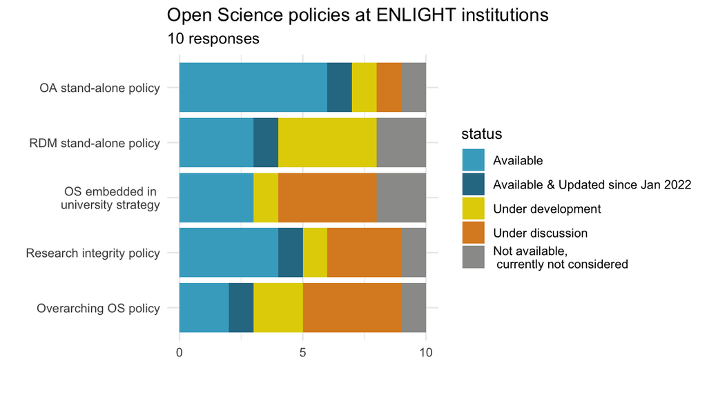

```r
# [28] "policy_oa_stand_alone"      "policy_rdm_stand_alone"    "policy_os_overarching"
# "policy_ri"                  "policy_univ_strategy"


os_policies_2024 <- os_survey_2024 %>%
  select(institution, policy_oa_stand_alone:policy_univ_strategy) %>%
  pivot_longer(policy_oa_stand_alone:policy_univ_strategy, names_to = "policy", values_to = "status") %>%
  mutate(policy = factor(policy, levels = c("policy_os_overarching", "policy_ri",  "policy_univ_strategy", "policy_rdm_stand_alone", "policy_oa_stand_alone"), labels = c("Overarching OS policy", "Research integrity policy", "OS embedded in \n university strategy", "RDM stand-alone policy", "OA stand-alone policy")), status = factor(status, labels = c("Not available, \n currently not considered", "Under discussion", "Under development", "Available & Updated since Jan 2022", "Available"), levels = c("Not available, currently not considered", "Under discussion", "Under development", "Available & Updated since January 2022", "Available")))

standard_plot4(os_policies_2024, policy, fill = status, title = "Open Science policies at ENLIGHT institutions", m = 10, subtitle = "responses", caption = "") + scale_y_continuous(limits = c(0, 10), breaks = c(0, 5, 10))
```

```r
# policy link
os_survey_2024 %>% filter(!is.na(policy_link)) %>% select(policy_link)
```

```
# A tibble: 8 × 1
  policy_link
  <chr>
1 https://www.ub.unibe.ch/services/open_science/open_access/oa_vt/oa/index_eng.…
2 http://library.universityofgalway.ie
3 https://eetika.ee/en/content/estonian-code-conduct-research-integrity
4 Open Access Policy (2016), https://www.uni-goettingen.de/de/document/download…
5 https://www.ehu.eus/es/web/biblioteka/política-institucional-y-marco-legal
6 https://www.rug.nl/research/openscience/ug-open-science-program/?lang=en
7 policy scholarly publishing: https://www.ugent.be/en/research/openscience/sch…
8 https://bibliotheques.u-bordeaux.fr/Soutien-a-la-recherche/Science-ouverte-l-…
```

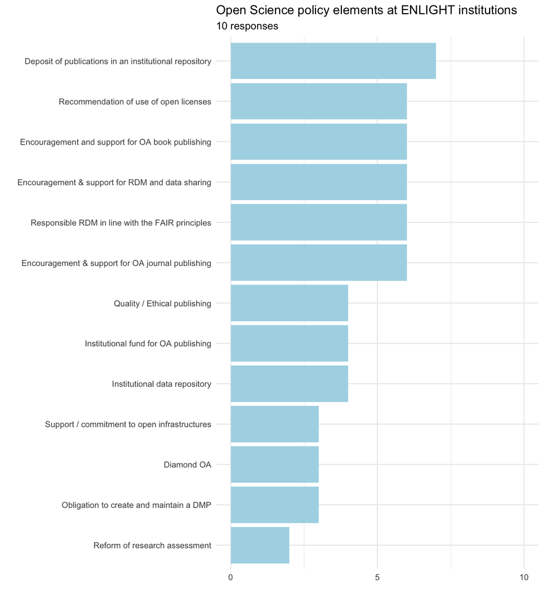

```r
# policy elements
os_policy_elements_tab_2024 <-
  os_survey_2024 %>% select(Zeitstempel, os_policy_elements, institution) %>%
  transform(os_policy_elements = strsplit(os_policy_elements, ",")) %>%
  unnest(os_policy_elements)  %>%
  transform(os_policy_elements = str_trim(os_policy_elements, side = "both")) %>%
  as_tibble() %>%
  filter(!is.na(os_policy_elements)) %>%
  mutate(os_policy_elements = factor(os_policy_elements))

os_policy_elements_tab_2024 <- os_policy_elements_tab_2024 %>%
  filter(!(os_policy_elements %in% c("We expect that in the next 2 years the institutional data repository will become a reality.", "Most elements above will be covered when a policy is ready."))) %>%
  mutate(os_policy_elements = recode_factor(os_policy_elements, "Encouragement and support for OA journal publishing (e.g. institutional journal hosting)" = "Encouragement & support for OA journal publishing", "Responsible management of research data in line with the FAIR principles" = "Responsible RDM in line with the FAIR principles", "Obligation to create and maintain a data management plan" = "Obligation to create and maintain a DMP",  "Encouragement and support for data management and data sharing" = "Encouragement & support for RDM and data sharing"))


standard_plot(os_policy_elements_tab_2024, os_policy_elements, title = "Open Science policy elements at ENLIGHT institutions", subtitle = "10 responses", caption = "") + scale_y_continuous(limits = c(0, 10), breaks = c(0, 5, 10))
```

```r
# free text on compliance monitoring
os_survey_2024 %>% filter(!is.na(compliance_monitoring)) %>% select(compliance_monitoring)
```

```
# A tibble: 9 × 1
  compliance_monitoring
  <chr>
1 "Boris / Swiss OA monitor / Open APC / Dimensions"
2 "university registry of publication outputs of CU staff with OA indication; i…
3 "Only monitoring tool so far is trying to assess the number/percentage of OA-…
4 "Partner in the National Open Access Monitor (Funding from Ireland National O…
5 "none"
6 "While there isn't an overarching monitoring system for all funder regulation…
7 "Only open access is monitored. The use of APCs corresponding to transformati…
8 "The Flemish open science policy plan 2019-2024 introduces some KPIs, which a…
9 "Open Science Barometer"
```

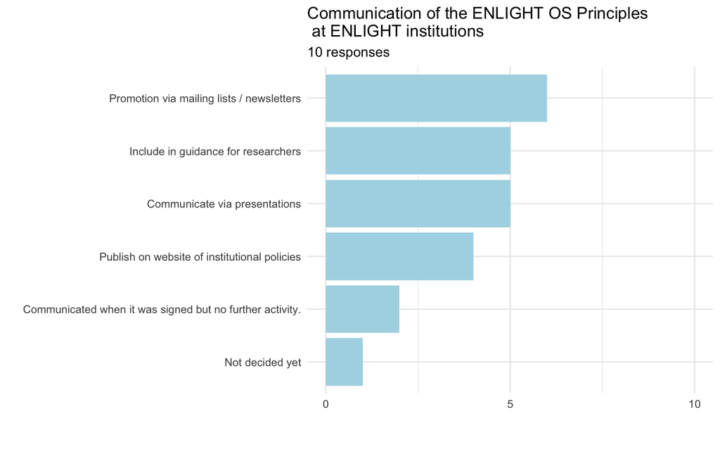

```r
#' communication of ENLIGHT OS principles
comms_os_policy_tab_2024 <-
  os_survey_2024 %>% select(Zeitstempel, comm_enlight_os_principles, institution) %>%
  transform(comm_enlight_os_principles = strsplit(comm_enlight_os_principles, ",")) %>%
  unnest(comm_enlight_os_principles)  %>%
  transform(comm_enlight_os_principles = str_trim(comm_enlight_os_principles, side = "both")) %>%
  as_tibble() %>%
  filter(!is.na(comm_enlight_os_principles)) %>%
  mutate(comm_enlight_os_principles = factor(comm_enlight_os_principles))

comms_os_policy_tab_2024 <- comms_os_policy_tab_2024 %>%
  filter(!(comm_enlight_os_principles %in% c("but after that no active communication/dissemination. It will be a helpful tool when developing local policies."))) %>%
  mutate(comm_enlight_os_principles = recode_factor(comm_enlight_os_principles, "The policy was noted when it was signed" = "Communicated when it was signed but no further activity.", "The Enlight OS Principles have been published in the University news. The rector's team informs us that nothing else is planned for the time being." = "Communicated when it was signed but no further activity."))

standard_plot(comms_os_policy_tab_2024, comm_enlight_os_principles, title = "Communication of the ENLIGHT OS Principles \n at ENLIGHT institutions", subtitle = "10 responses", caption = "") + scale_y_continuous(limits = c(0, 10), breaks = c(0, 5, 10))
```

## Recognition and rewards

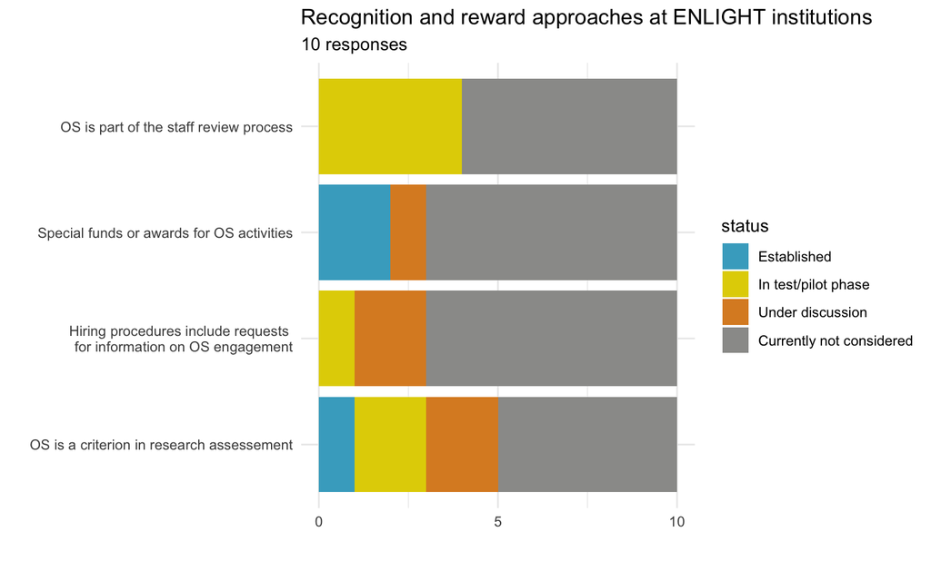

```r
# [37] "rr_approaches_os_criteria"  "rr_approaches_hiring"       "rr_approaches_os_funds"
# [40] "rr_approaches_staff_review" "coara_membership"

# Recognition and reward approaches in ENLIGHT
rr_approaches_2024 <- os_survey_2024 %>% select(institution, rr_approaches_os_criteria:rr_approaches_staff_review) %>% pivot_longer(rr_approaches_os_criteria:rr_approaches_staff_review, names_to = "approach", values_to = "status") %>% mutate(approach = factor(approach, levels = c("rr_approaches_os_criteria", "rr_approaches_hiring", "rr_approaches_os_funds", "rr_approaches_staff_review"), labels = c("OS is a criterion in research assessement", "Hiring procedures include requests \n for information on OS engagement", "Special funds or awards for OS activities", "OS is part of the staff review process")), status = factor(status, levels = c("Currently not considered", "Under discussion", "In test/pilot phase", "Established")))

standard_plot3(rr_approaches_2024, approach, fill = status, title = "Recognition and reward approaches at ENLIGHT institutions", m = 10, subtitle = "responses", caption = "") + scale_y_continuous(limits = c(0, 10), breaks = c(0, 5, 10))
```

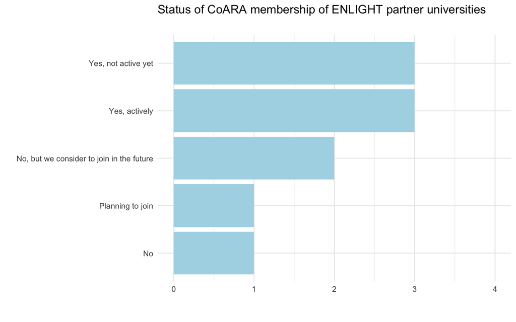

```r
# coara membership
standard_plot(os_survey_2024, coara_membership, title = "Status of CoARA membership of ENLIGHT partner universities", subtitle = "", caption = "") + scale_y_continuous(limits = c(0, 4), breaks = c(0, 1, 2, 3, 4))
```

## Joint achievements and future activities

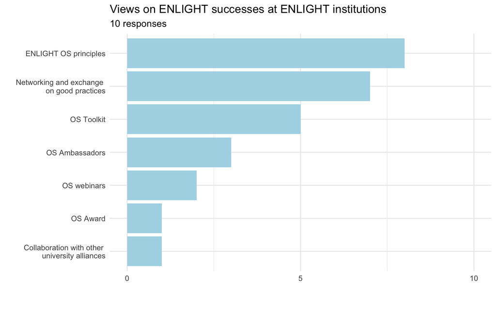

```r
# "enlight_successes"
# [43] "enlight_benefits"           "enlight_continue"
# [46] "enlight_wg_needs"

# ENLIGHT successes
enlight_successes_tab_2024 <-
  os_survey_2024 %>% select(Zeitstempel, enlight_successes, institution) %>%
  transform(enlight_successes = strsplit(enlight_successes, ",")) %>%
  unnest(enlight_successes)  %>%
  transform(enlight_successes = str_trim(enlight_successes, side = "both")) %>%
  as_tibble() %>%
  filter(!is.na(enlight_successes)) %>%
  mutate(enlight_successes = factor(enlight_successes))

enlight_successes_tab_2024 <- enlight_successes_tab_2024 %>%
  filter(!(enlight_successes %in% c(""))) %>%
  mutate(enlight_successes = recode_factor(enlight_successes, "Networking and exchange on good practices with Open Science and other experts" = "Networking and exchange \n on good practices", "Development and agreement on joint ENLIGHT Open Science principles" = "ENLIGHT OS principles", "Joint development and implementation of the ENLIGHT OS Ambassadors" = "OS Ambassadors", "Joint creation of the ENLIGHT Open Science Toolkit" = "OS Toolkit", "eg webinars" = "OS webinars", "joint OS Webinar Series" = "OS webinars", "collaboration with other alliances" = "Collaboration with other \n university alliances", "joint OS Award" = "OS Award"))
standard_plot(enlight_successes_tab_2024, enlight_successes, title = "Views on ENLIGHT successes at ENLIGHT institutions", subtitle = "10 responses", caption = "") + scale_y_continuous(limits = c(0, 10), breaks = c(0, 5, 10))
```

```r
# free text on ENLIGHT benefits
os_survey_2024 %>% filter(!is.na(enlight_benefits)) %>% select(enlight_benefits)
```

```
# A tibble: 9 × 1
  enlight_benefits
  <chr>
1 "none so far"
2 "We expanded the scope of OA trainings, especially for doctoral students (a l…
3 "I has helped to establish OS as an entity that the university needs to relat…
4 "Development of the ENLIGHT OS toolkit which is a great resource for new acad…
5 "Open Science principles"
6 "Increased OS awareness, greater consideration of practical implementation of…
7 "The signing in Uppsala of the Open Science Principles by the rectors should …
8 "The Open Science principles triggered discussions around future evolution of…
9 "Open science ambassadors"
```

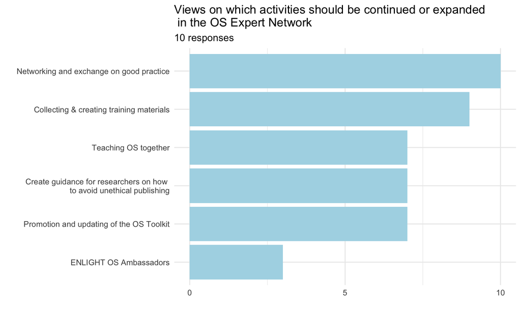

```r
# Suggestions on what to continue in ENLIGHT 2.0 / Expert network
enlight_continue_tab_2024 <-
  os_survey_2024 %>% select(Zeitstempel, enlight_continue, institution) %>%
  transform(enlight_continue = strsplit(enlight_continue, ",")) %>%
  unnest(enlight_continue)  %>%
  transform(enlight_continue = str_trim(enlight_continue, side = "both")) %>%
  as_tibble() %>%
  filter(!is.na(enlight_continue)) %>%
  mutate(enlight_continue = factor(enlight_continue))

enlight_continue_tab_2024 <- enlight_continue_tab_2024 %>%
  filter(!(enlight_continue %in% c("it might be difficult to maintain activities like Ambassadors and OS Toolkit.", "If OS is no longer part of a WP"))) %>%
  mutate(enlight_continue = recode_factor(enlight_continue, "Networking and exchange on good practices with Open Science and other experts" = "Networking and exchange on good practice", "Promotion and updating of the ENLIGHT Open Science Toolkit" = "Promotion and updating of the OS Toolkit", "Create guidance for researchers on how to avoid unethical publishing" = "Create guidance for researchers on how \n to avoid unethical publishing", "Teaching Open Science together (incl. curriculum integration)" = "Teaching OS together", "Collecting and creating training materials" = "Collecting & creating training materials", "Joint support and use of the ENLIGHT OS Ambassadors" = "ENLIGHT OS Ambassadors"))
standard_plot(enlight_continue_tab_2024, enlight_continue, title = "Views on which activities should be continued or expanded \n in the OS Expert Network", subtitle = "10 responses", caption = "") + scale_y_continuous(limits = c(0, 10), breaks = c(0, 5, 10))
```

```r
# free text suggestions for ENLIGHT OS trainings
os_survey_2024 %>% filter(!is.na(enlight_training_sugg)) %>% select(enlight_training_sugg)
```

```
# A tibble: 6 × 1
  enlight_training_sugg
  <chr>
1 "Copyright / summer school"
2 "reasearch assessment/evaluation that takes into account OA vs bibliometrics …
3 "Data skills and data sharing\nHow researchers can incorporate Citizen Scienc…
4 "e.g. basic data skills and data management on BA and MA level, adapted to va…
5 "- ethical publishing (How to deal with paper mills? How to deal with trainin…
6 "-Collaborative development of open science e-learning content\n-Joint events…
```

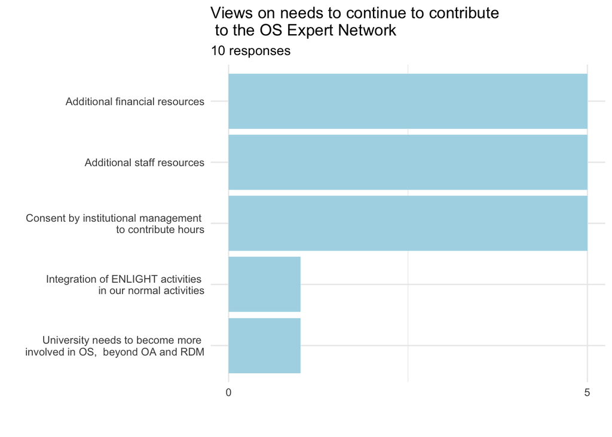

```r
# enlight_wg_needs

# Suggestions on what to continue in ENLIGHT 2.0 / Expert network
enlight_wg_needs_tab_2024 <-
  os_survey_2024 %>% select(Zeitstempel, enlight_wg_needs, institution) %>%
  transform(enlight_wg_needs = strsplit(enlight_wg_needs, ",")) %>%
  unnest(enlight_wg_needs)  %>%
  transform(enlight_wg_needs = str_trim(enlight_wg_needs, side = "both")) %>%
  as_tibble() %>%
  filter(!is.na(enlight_wg_needs)) %>%
  mutate(enlight_wg_needs = factor(enlight_wg_needs))

enlight_wg_needs_tab_2024 <- enlight_wg_needs_tab_2024 %>%
  filter(!(enlight_wg_needs %in% c("consent would be handy", "in support of our research community"))) %>%
  mutate(enlight_wg_needs = recode_factor(enlight_wg_needs, "I think the most important thing at the moment is for the University to become more involved in open science and to promote the creation of a multidisciplinary team to promote it. The initiatives underway have to do only with open access to publications and data and are generally led only by the library." = "University needs to become more \n involved in OS,  beyond OA and RDM", "but we mainly need to be able to integrate ENLIGHT activities in our normal activities in the university. In other words" = "Integration of ENLIGHT activities \n in our normal activities", "Consent by institutional management to contribute hours" = "Consent by institutional management \n to contribute hours",      "Additional staff resources in the contributing unit(s)" = "Additional staff resources", "Additional financial resources (e.g. travel costs)" = "Additional financial resources"))

standard_plot(enlight_wg_needs_tab_2024, enlight_wg_needs, title = "Views on needs to continue to contribute \n to the OS Expert Network", subtitle = "10 responses", caption = "") + scale_y_continuous(limits = c(0, 5), breaks = c(0, 5))
```

## Research data management and FAIR data

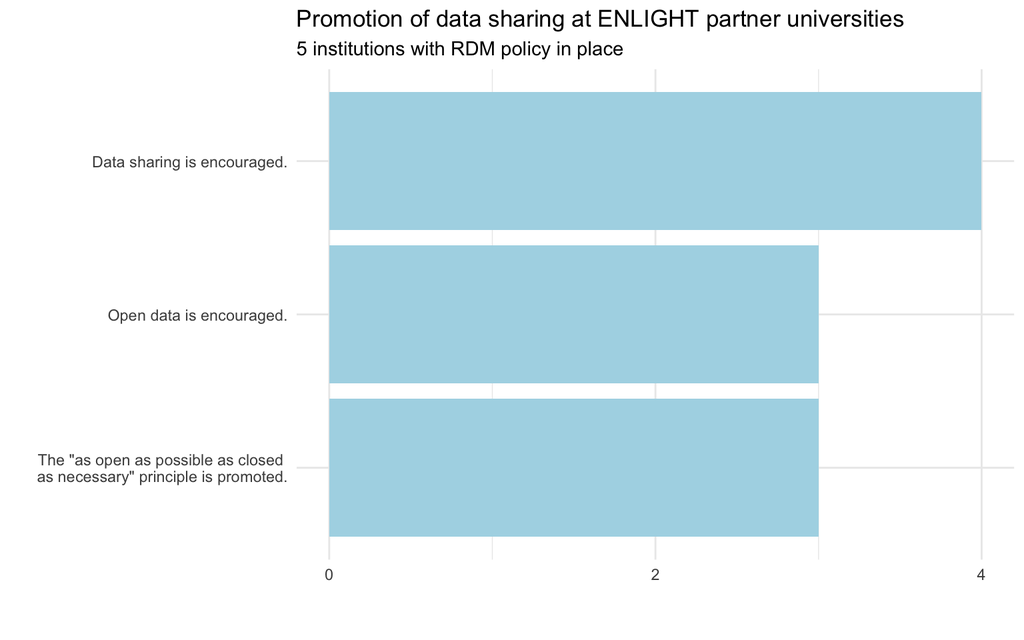

```r
# relevant variables
# "rdm_policy_data_sharing"    "rdm_policy_fair"
# "rdm_services"               "rdm_staff"                  "rdm_actions"
# "fair_challenges"


# RDM policies - data sharing
rdm_policy_data_sharing_tab_2024 <- os_survey_2024 %>%
  select(Zeitstempel, rdm_policy_data_sharing) %>%
  transform(rdm_policy_data_sharing = strsplit(rdm_policy_data_sharing, ",")) %>%
  unnest(rdm_policy_data_sharing) %>%
  transform(rdm_policy_data_sharing = str_trim(rdm_policy_data_sharing, side = "both")) %>%
  as_tibble() %>%
  filter(!is.na(rdm_policy_data_sharing)) %>%
  mutate(rdm_policy_data_sharing = factor(rdm_policy_data_sharing)) %>%
  filter(!(rdm_policy_data_sharing %in% c("RDP is only under construction at our university", 'but we are thinking about "as open as possible..." principle', "No policy yet :-(", "no policy", "The data repository project and the research data policy are expected to become a reality in the next 2 years."))) %>%
  mutate(rdm_policy_data_sharing = recode_factor(rdm_policy_data_sharing,
'The "as open as possible as closed as necessary" principle is promoted.' = 'The "as open as possible as closed \n as necessary" principle is promoted.'))

standard_plot(rdm_policy_data_sharing_tab_2024, rdm_policy_data_sharing, title = "Promotion of data sharing at ENLIGHT partner universities", subtitle = "5 institutions with RDM policy in place", caption = "") + scale_y_continuous(limits = c(0, 4), breaks = c(0, 2, 4))
```

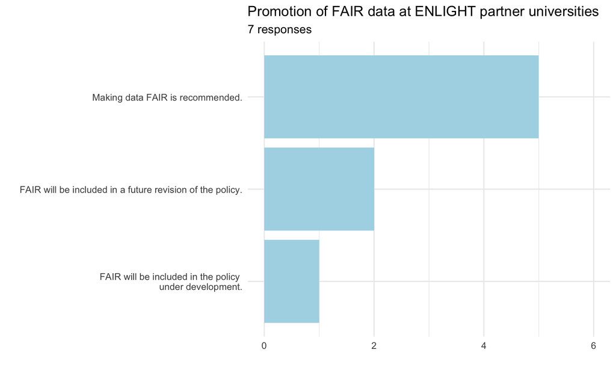

```r
# RDM policies - FAIR data
rdm_policy_fair_tab_2024 <- os_survey_2024 %>%
  select(Zeitstempel, rdm_policy_fair) %>%
  transform(rdm_policy_fair = strsplit(rdm_policy_fair, ",")) %>%
  unnest(rdm_policy_fair) %>%
  transform(rdm_policy_fair = str_trim(rdm_policy_fair, side = "both")) %>%
  as_tibble() %>%
  filter(!is.na(rdm_policy_fair)) %>%
  mutate(rdm_policy_fair = factor(rdm_policy_fair)) %>%
  filter(!(rdm_policy_fair %in% c("no policy"))) %>%
  mutate(rdm_policy_fair = recode_factor(rdm_policy_fair, "FAIR will be included in the policy under development." = "FAIR will be included in the policy \n under development."))

standard_plot(rdm_policy_fair_tab_2024, rdm_policy_fair, title = "Promotion of FAIR data at ENLIGHT partner universities", subtitle = "7 responses", caption = "") + scale_y_continuous(limits = c(0, 6), breaks = c(0, 2, 4, 6))
```

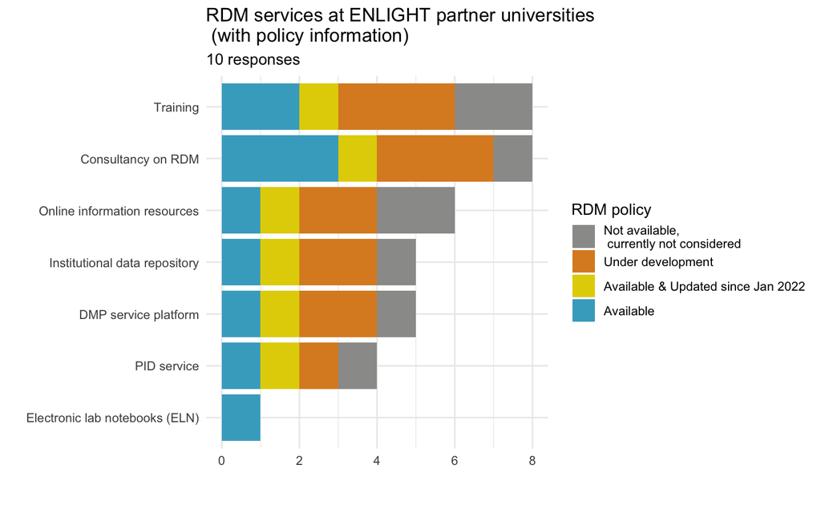

```r
# RDM services
rdm_services_tab_2024 <- os_survey_2024 %>%
  select(Zeitstempel, rdm_services, policy_rdm_stand_alone) %>%
  transform(rdm_services = strsplit(rdm_services, ",")) %>%
  unnest(rdm_services)  %>%
  transform(rdm_services = str_trim(rdm_services, side = "both")) %>%
  as_tibble() %>%
  filter(!is.na(rdm_services)) %>%
  mutate(rdm_services = factor(rdm_services)) %>%
  filter(!(rdm_services %in% c("see previous answers.", "DMPs)", "hosting of DMPs)", "tools)", "In planning", "Training", "infrastructures"))) %>%
  mutate(rdm_services = recode_factor(rdm_services,
"Consultancy on data management (e.g. funder requirements" = "Consultancy on RDM", "DMP service platform (creation" = "DMP service platform", "Training (e.g. RDM" = "Training")) %>%
  mutate(policy_rdm_stand_alone = factor(policy_rdm_stand_alone, labels = c("Not available, \n currently not considered", "Under discussion", "Under development", "Available & Updated since Jan 2022", "Available"), levels = c("Not available, currently not considered", "Under discussion", "Under development", "Available & Updated since January 2022", "Available")))
#%>%  count(rdm_services) %>% arrange(desc(n))

standard_plot3(rdm_services_tab_2024, rdm_services, fill = policy_rdm_stand_alone, title = "RDM services at ENLIGHT partner universities \n (with policy information)", m = 10, subtitle = "responses", caption = "") + guides(fill=guide_legend(title="RDM policy"))
```

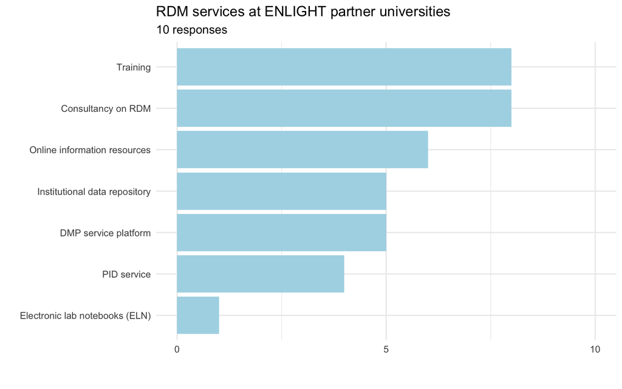

```r
standard_plot(rdm_services_tab_2024, rdm_services, title = "RDM services at ENLIGHT partner universities", subtitle = "10 responses", caption = "") + scale_y_continuous(limits = c(0, 10), breaks = c(0, 5, 10))
```

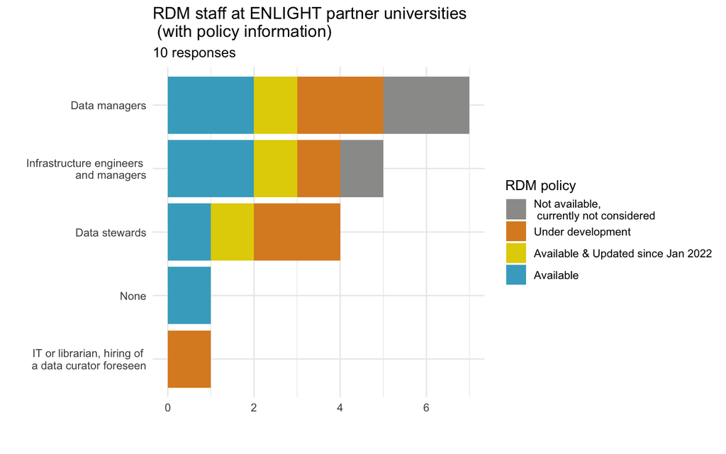

```r
# RDM staff
rdm_staff_tab_2024 <- os_survey_2024 %>%
  select(Zeitstempel, rdm_staff, policy_rdm_stand_alone) %>%
  transform(rdm_staff = strsplit(rdm_staff, ",")) %>%
  unnest(rdm_staff)  %>%
  transform(rdm_staff = str_trim(rdm_staff, side = "both")) %>%
  as_tibble() %>%
  filter(!is.na(rdm_staff)) %>%
  mutate(rdm_staff = factor(rdm_staff)) %>%
  filter(!(rdm_staff %in% c("data curators)", "directly linked to or embedded in a department/project)", "data librarians", "is the university's own at the moment.", "The project to set up the data repository that we have just started includes the hiring of a data curator. The rest of the staff", "The university also partly rely on data stewards that are connected to national infrastructures/competence centers."))) %>%
  mutate(rdm_staff = recode_factor(rdm_staff, "Data managers (e.g. research data managers" = "Data managers", "Infrastructure engineers and managers (e.g. data repository developer)" = " Infrastructure engineers \n and managers", "Dedicated data stewards (implementation and liaison role" = "Data stewards", "IT or librarian" = "IT or librarian, hiring of \n a data curator foreseen")) %>%
  mutate(policy_rdm_stand_alone = factor(policy_rdm_stand_alone, labels = c("Not available, \n currently not considered", "Under discussion", "Under development", "Available & Updated since Jan 2022", "Available"), levels = c("Not available, currently not considered", "Under discussion", "Under development", "Available & Updated since January 2022", "Available")))


standard_plot3(rdm_staff_tab_2024, rdm_staff, fill = policy_rdm_stand_alone, title = "RDM staff at ENLIGHT partner universities \n (with policy information)", m = 10, subtitle = "responses", caption = "") + guides(fill=guide_legend(title="RDM policy"))
```

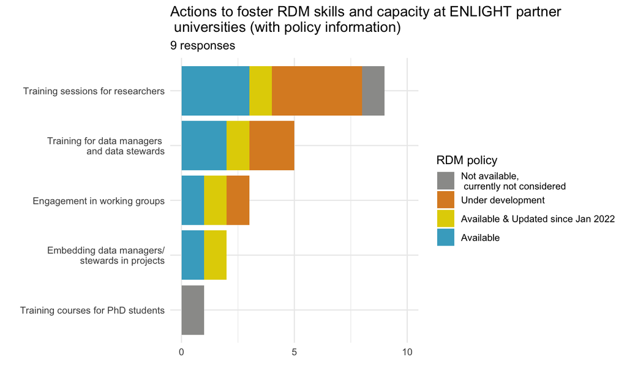

```r
# rdm_actions
# What actions are currently taken for fostering skills and capacities for RDM and making data FAIR? (Multiple choice possible)

rdm_actions_tab_2024 <- os_survey_2024 %>%
  select(Zeitstempel, rdm_actions, policy_rdm_stand_alone) %>%
    transform(rdm_actions = strsplit(rdm_actions, ",")) %>%
  unnest(rdm_actions)  %>%
  transform(rdm_actions = str_trim(rdm_actions, side = "both")) %>%
  as_tibble() %>%
  filter(!is.na(rdm_actions)) %>%
  mutate(rdm_actions = factor(rdm_actions)) %>%
  filter(!(rdm_actions %in% c("but on a limited level."))) %>%
  mutate(rdm_actions = recode_factor(rdm_actions, "Training for researchers exist" = "Training sessions for researchers", "Training courses for PHD students" = "Training courses for PhD students", "Embedding data managers/stewards in projects" = "Embedding data managers/\nstewards in projects", "Engagement in working groups (e.g. RDA)" = "Engagement in working groups", "Training for data managers and data stewards" = "Training for data managers \n and data stewards")) %>%
  mutate(policy_rdm_stand_alone = factor(policy_rdm_stand_alone, labels = c("Not available, \n currently not considered", "Under discussion", "Under development", "Available & Updated since Jan 2022", "Available"), levels = c("Not available, currently not considered", "Under discussion", "Under development", "Available & Updated since January 2022", "Available")))

standard_plot3(rdm_actions_tab_2024, rdm_actions, fill = policy_rdm_stand_alone, title = "Actions to foster RDM skills and capacity at ENLIGHT partner \n universities (with policy information)", m = 9, subtitle = "responses", caption = "") + guides(fill=guide_legend(title="RDM policy")) + scale_y_continuous(limits = c(0, 10), breaks = c(0, 5, 10))
```

```r
# fair_challenges
os_survey_2024 %>% select(fair_challenges) %>% filter(!is.na(fair_challenges)) %>% unique()
```

```
# A tibble: 7 × 1
  fair_challenges
  <chr>
1 "differences between subjects / faculties at university"
2 "lack of proper infrastruction; \nlack of awareness/skills among researchers …
3 "Lack of merit/rewards."
4 "Data roles to ensure Data Quality and Standardisation as well as Data Govern…
5 "- Some researchers lack RDM awareness. \n- Not all researchers know about th…
6 "- Developing sustainable, FAIR enabling infrastructure\n- Difficult to monit…
7 "The implementation of a comprehensive policy on research data and FAIR princ…
```